# re_ml01

Valentin Lanz

2025-04-28

In this exercise, I am going to look at the differences between linear regression models and KNN supervised machine learning models.

```r
#load libraries
library(dplyr)
library(ggplot2)
library(readr)
library(tidyr)
library(caret)
library(recipes)

#load functions
source("../R/agds10_functions.R")



#load data
url_fluxes <- "https://raw.githubusercontent.com/geco-bern/agds_book/refs/heads/main/book/data/FLX_CH-Dav_FLUXNET2015_FULLSET_DD_1997-2014_1-3.csv"

daily_fluxes <- read.table(
  url_fluxes,
  header = TRUE,
  sep = ","
)


daily_fluxes <- daily_fluxes |>

  # select only the variables we are interested in
  dplyr::select(TIMESTAMP,
                GPP_NT_VUT_REF,    # the target
                ends_with("_QC"),  # quality control info
                ends_with("_F"),   # includes all all meteorological covariates
                -contains("JSB")   # weird useless variable
  ) |>

  # convert to a nice date object
  dplyr::mutate(TIMESTAMP = lubridate::ymd(TIMESTAMP)) |>

  # set all -9999 to NA
  mutate(across(where(is.numeric), ~na_if(., -9999))) |>

  # retain only data based on >=80% good-quality measurements
  # overwrite bad data with NA (not dropping rows)
  dplyr::mutate(GPP_NT_VUT_REF = ifelse(NEE_VUT_REF_QC < 0.8, NA, GPP_NT_VUT_REF),
                TA_F           = ifelse(TA_F_QC        < 0.8, NA, TA_F),
                SW_IN_F        = ifelse(SW_IN_F_QC     < 0.8, NA, SW_IN_F),
                LW_IN_F        = ifelse(LW_IN_F_QC     < 0.8, NA, LW_IN_F),
                VPD_F          = ifelse(VPD_F_QC       < 0.8, NA, VPD_F),
                PA_F           = ifelse(PA_F_QC        < 0.8, NA, PA_F),
                P_F            = ifelse(P_F_QC         < 0.8, NA, P_F),
                WS_F           = ifelse(WS_F_QC        < 0.8, NA, WS_F)) |>

  # drop QC variables (no longer needed)
  dplyr::select(-ends_with("_QC"))





#split data
split <- rsample::initial_split(daily_fluxes, prop = 0.7, strata = "VPD_F")
daily_fluxes_train <- rsample::training(split)
daily_fluxes_test <- rsample::testing(split)




# scale and center data, Yeo-Johnson transform
pp <- recipes::recipe(GPP_NT_VUT_REF ~ SW_IN_F + VPD_F + TA_F,
                      data = daily_fluxes_train |> drop_na()) |>
  recipes::step_YeoJohnson(recipes::all_predictors()) |>
  recipes::step_center(recipes::all_numeric(), -recipes::all_outcomes()) |>
  recipes::step_scale(recipes::all_numeric(), -recipes::all_outcomes())




# Fit linear regression model
mod_lm <- caret::train(
  pp,
  data = daily_fluxes_train |> drop_na(),
  method = "lm",
  trControl = caret::trainControl(method = "none"),
  metric = "RMSE"
)

# Fit KNN model
mod_knn <- caret::train(
  pp,
  data = daily_fluxes_train |> drop_na(),
  method = "knn",
  trControl = caret::trainControl(method = "none"),
  tuneGrid = data.frame(k = 8),
  metric = "RMSE"
)
```

## Comparison of linear model and KNN model

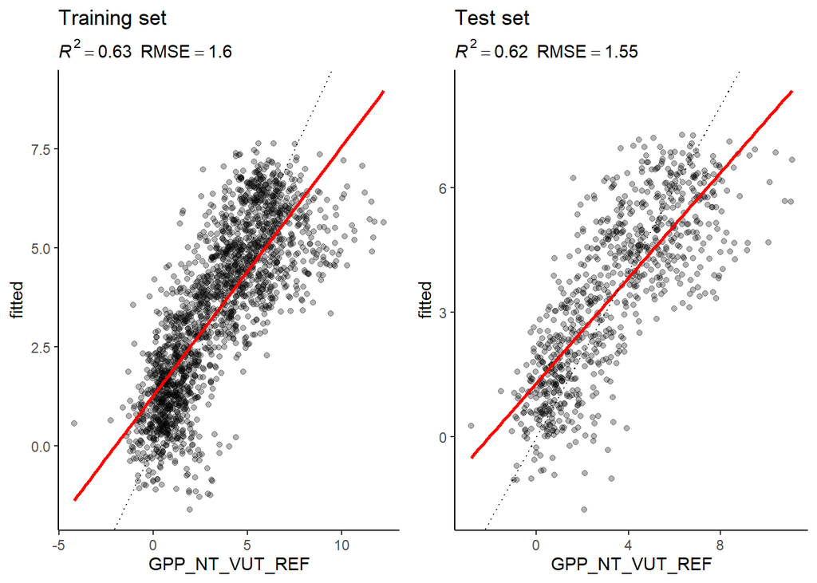

```r
#fit linear model
lm_results <- eval_model(mod = mod_lm, df_train = daily_fluxes_train, df_test = daily_fluxes_test)


#show scatter plot of training and test data
lm_results$plots
```

Linear Model Evaluation

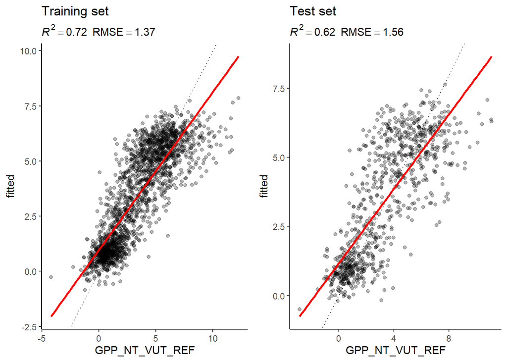

```r
# fit KNN model
knn_results_8 <- eval_model(mod = mod_knn, df_train = daily_fluxes_train, df_test = daily_fluxes_test)


#show scatter plot of training and test data
knn_results_8$plots
```

KNN Model Evaluation

**Evaluation: KNN vs. linear model**

As we see, there is a significant difference between the R<sup>2</sup> of the training set and the R<sup>2</sup> of the test set. This might be due to overfitting of the model. It makes sense that the model is more accurate for the data with which it was trained and not as accurate when tested with an unknown data set.

This difference is smaller in the linear model. This is because the linear model uses a global approach and is less vulnerable to overfitting. The linear model does not as much depend on the specific distribution of the training data as the KNN model. Instead, the linear model uses “all training data at once” for training. It generalizes better.

The linear model has a stronger bias and less variance because it uses all observations at once when trained.

The KNN model has a higher variance than the linear model, but the KNN’s variance depends on the value that k takes. With increasing number of neighbors (k), the bias increases and the variance gets lower. In the extreme case of k being equal to n (number of observations), the model has maximum bias and no variation at all (all observations are used as neighbors).

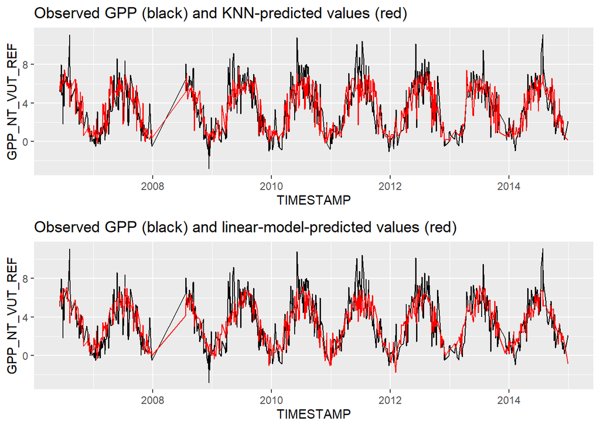

```r
#plot knn-modelled GPP (k=8) and compare to observed values
compare_plot_knn <- ggplot(data = knn_results_8$predict_test) +
  geom_line(aes(x = TIMESTAMP, y = GPP_NT_VUT_REF)) +
  geom_line(aes(x = TIMESTAMP, y = fitted), color = "red") +
  labs(title = "Observed GPP (black) and KNN-predicted values (red)")



#plot linear model predicted GPP and compare to observed values
compare_plot_lm <- ggplot(data = lm_results$predict_test) +
  geom_line(aes(x = TIMESTAMP, y = GPP_NT_VUT_REF)) +
  geom_line(aes(x = TIMESTAMP, y = fitted), color = "red") +
  labs(title = "Observed GPP (black) and linear-model-predicted values (red)")


#combine plots
cowplot::plot_grid(compare_plot_knn, compare_plot_lm, nrow = 2)
```

## The role of k

My hypothesis is that for k approaching 1, on the training set the R<sup>2</sup> will be near 1 and the MAE near 0. On the test set the R<sup>2</sup> will be very low due to overfitting and the MAE will be accordingly high.

For k approaching n, on the training set I expect the R<sup>2</sup> to be quite bad (underfitting) and the MAE will probably be bad too. On the test set there will be a better R<sup>2</sup> than the k = 1 model, but not a solid one because of underfitting.

```r
knn_results <- data.frame(k = 8, knn_results_8$metrics)



#set up a for loop to increase k and analyse the relevant metrics

for (k1 in c((1:40), (150:170), (280:300))) {


  #fit knn model with k1 neighbours
  mod_k1nn <- caret::train(
  pp,
  data = daily_fluxes_train |> drop_na(),
  method = "knn",
  trControl = caret::trainControl(method = "none"),
  tuneGrid = data.frame(k = k1),
  metric = "RMSE"
  )

  #extract metrics
  k1_results <- eval_model(mod_k1nn, df_train = daily_fluxes_train, df_test = daily_fluxes_test)


  #add column to keep track of k
  df_k1_results <- data.frame(k = k1, k1_results$metrics)
  knn_results <- rbind(knn_results, df_k1_results)

}
```

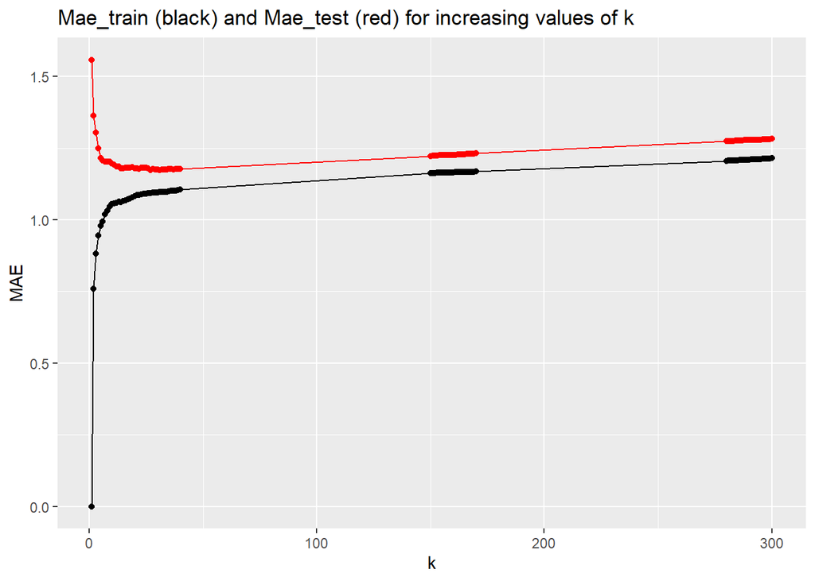

```r
#plot mae_train and mae_test against k

k_plot <- ggplot(data = knn_results) +
  geom_line(aes(x = k, y = Mae_train)) +
  geom_point(aes(x = k, y = Mae_train)) +
  geom_line(aes(x = k, y = Mae_test), color = "red") +
  geom_point(aes(x = k, y = Mae_test), color = "red") +
  labs(title = "Mae_train (black) and Mae_test (red) for increasing values of k",
       y = "MAE")




k_plot
```

For low values of k, the mean absolute error is very low on the training set because the model precisely fits the training data and has low bias. On the test set, however, the MAE is high because of the overfitting mentioned before.

As k increases, the model gets more general (more bias, less variance). On the right side of the plot we see that MAE is quite high on both the test and training set. This is due to underfitting. The model is too simple.

```r
#find optimal k, where MAE is minimal

sorted_mae <- knn_results |> dplyr::arrange(Mae_test)


#select ks with lowest mae_test
lowest_10_mae <- sorted_mae[1:10, 1:2]

knitr::kable(lowest_10_mae, align = "c")
```

| k | Mae_test |
| --- | --- |
| 27 | 1.172850 |
| 31 | 1.173948 |
| 32 | 1.174665 |
| 30 | 1.174950 |
| 33 | 1.175044 |
| 34 | 1.175617 |
| 29 | 1.175859 |
| 37 | 1.176374 |
| 40 | 1.176462 |
| 36 | 1.176749 |

The region of optimal generalisability is found below k = 40. Sometimes, depending on the data split, it is even below k = 30.